# DATA 608 - Home Work1

Soumya Ghosh

August 29, 2019

### R Libraries:

Load necessary libraries -

```r
library(kableExtra)
library(dplyr)
library(ggplot2)
```

**Principles of Data Visualization and Introduction to ggplot2**

I have provided you with data about the 5,000 fastest growing companies in the US, as compiled by Inc. magazine. lets read this in:

```r
inc <- read.csv("https://raw.githubusercontent.com/charleyferrari/CUNY_DATA_608/master/module1/Data/inc5000_data.csv", header= TRUE)
```

And lets preview this data:

```r
#head(inc)
head(inc) %>% kable() %>% kable_styling(bootstrap_options = c("striped", "hover", "condensed", "responsive")) %>% scroll_box(width="100%",height="300px")
```

| Rank | Name | Growth_Rate | Revenue | Industry | Employees | City | State |
| --- | --- | --- | --- | --- | --- | --- | --- |
| 1 | Fuhu | 421.48 | 1.179e+08 | Consumer Products & Services | 104 | El Segundo | CA |
| 2 | FederalConference.com | 248.31 | 4.960e+07 | Government Services | 51 | Dumfries | VA |
| 3 | The HCI Group | 245.45 | 2.550e+07 | Health | 132 | Jacksonville | FL |
| 4 | Bridger | 233.08 | 1.900e+09 | Energy | 50 | Addison | TX |
| 5 | DataXu | 213.37 | 8.700e+07 | Advertising & Marketing | 220 | Boston | MA |
| 6 | MileStone Community Builders | 179.38 | 4.570e+07 | Real Estate | 63 | Austin | TX |

```r
# Apply Complete.cases() function to exclude records with null values in any of the columns

inc <- inc[complete.cases(inc),]

summary(inc)
```

```
##       Rank                          Name       Growth_Rate
##  Min.   :   1   (Add)ventures         :   1   Min.   :  0.340
##  1st Qu.:1252   @Properties           :   1   1st Qu.:  0.770
##  Median :2502   1-Stop Translation USA:   1   Median :  1.420
##  Mean   :2501   110 Consulting        :   1   Mean   :  4.615
##  3rd Qu.:3750   11thStreetCoffee.com  :   1   3rd Qu.:  3.290
##  Max.   :5000   123 Exteriors         :   1   Max.   :421.480
##                 (Other)               :4983
##     Revenue                                  Industry      Employees
##  Min.   :2.000e+06   IT Services                 : 732   Min.   :    1.0
##  1st Qu.:5.100e+06   Business Products & Services: 480   1st Qu.:   25.0
##  Median :1.090e+07   Advertising & Marketing     : 471   Median :   53.0
##  Mean   :4.825e+07   Health                      : 354   Mean   :  232.7
##  3rd Qu.:2.860e+07   Software                    : 341   3rd Qu.:  132.0
##  Max.   :1.010e+10   Financial Services          : 260   Max.   :66803.0
##                      (Other)                     :2351
##             City          State
##  New York     : 160   CA     : 700
##  Chicago      :  90   TX     : 386
##  Austin       :  88   NY     : 311
##  Houston      :  76   VA     : 283
##  San Francisco:  74   FL     : 282
##  Atlanta      :  73   IL     : 272
##  (Other)      :4428   (Other):2755
```

Think a bit on what these summaries mean. Use the space below to add some more relevant non-visual exploratory information you think helps you understand this data:

### High Level understanding from the statistical summary

A. Maximum no. of growing companies are located in state of CA in the West Coast most probably due to high concentration of start ups and tech firms

B. New York city in the East Coast has highest city level concentration of growing companies most likely due to being the major hub for banking and finanlcial industry

C. IT Services industry has highest no. of fast growing companies

D. The Employees count in the data set ranges from 1 to 67K and revenue from $2M to $10B+. So the data set includes growing companies of all sizes including start ups to much bigger corporate houses

```r
# Insert your code here, create more chunks as necessary

# Ranking of States based on Mean/Avg. Company Growth Rate
topGrowthStates <- inc %>% group_by(State) %>% summarise(Growth_Rate.mean = mean(Growth_Rate)) %>% mutate(rank = rank(-Growth_Rate.mean)) %>% arrange(rank)


topGrowthStates %>% kable() %>% kable_styling(bootstrap_options = c("striped", "hover", "condensed", "responsive")) %>% scroll_box(width="100%",height="300px")
```

| State | Growth_Rate.mean | rank |
| --- | --- | --- |
| WY | 19.145000 | 1 |
| ME | 16.210000 | 2 |
| RI | 16.031250 | 3 |
| DC | 8.439524 | 4 |
| HI | 6.792857 | 5 |
| UT | 6.307790 | 6 |
| SC | 6.060625 | 7 |
| TX | 6.036503 | 8 |
| CA | 5.900229 | 9 |
| FL | 5.846099 | 10 |
| MS | 5.642500 | 11 |
| MA | 5.416648 | 12 |
| CT | 4.994600 | 13 |
| MD | 4.984809 | 14 |
| CO | 4.971955 | 15 |
| TN | 4.950366 | 16 |
| VA | 4.877350 | 17 |
| AK | 4.805000 | 18 |
| IN | 4.788261 | 19 |
| AZ | 4.616700 | 20 |
| NJ | 4.445380 | 21 |
| NY | 4.371158 | 22 |
| WA | 4.020698 | 23 |
| MN | 3.821477 | 24 |
| IL | 3.751213 | 25 |
| KS | 3.628684 | 26 |
| OH | 3.557527 | 27 |
| GA | 3.522607 | 28 |
| NC | 3.393630 | 29 |
| OR | 3.148367 | 30 |
| OK | 3.097174 | 31 |
| WI | 2.739351 | 32 |
| ID | 2.645294 | 33 |
| PA | 2.578159 | 34 |
| MO | 2.497288 | 35 |
| DE | 2.420000 | 36 |
| AL | 2.407451 | 37 |
| NV | 2.330769 | 38 |
| MI | 2.238571 | 39 |
| NE | 2.078889 | 40 |
| KY | 2.064000 | 41 |
| LA | 1.944595 | 42 |
| IA | 1.761071 | 43 |
| PR | 1.730000 | 44 |
| AR | 1.670000 | 45 |
| NH | 1.512917 | 46 |
| SD | 1.406667 | 47 |
| NM | 1.364000 | 48 |
| VT | 1.296667 | 49 |
| ND | 1.227000 | 50 |
| MT | 0.762500 | 51 |
| WV | 0.620000 | 52 |

From above ranking of states for mean company growth rate, we can see even though CA has maximum no. of growing companies, but CA ranks 9th interms of avg. growth rate. WY has the maximum avg. growth rate, but has only 2 companies included in the data set.

```r
# Industry Revenue Share
industryRev <- inc %>% group_by(Industry) %>% summarise(TotalRevenue = sum(Revenue)) %>% mutate(share = TotalRevenue/sum(TotalRevenue)) %>% mutate(rank = rank(-share)) %>% arrange(rank)


industryRev %>% kable() %>% kable_styling(bootstrap_options = c("striped", "hover", "condensed", "responsive")) %>% scroll_box(width="100%",height="300px")
```

| Industry | TotalRevenue | share | rank |
| --- | --- | --- | --- |
| Business Products & Services | 26345900000 | 0.1094390 | 1 |
| IT Services | 20525000000 | 0.0852594 | 2 |
| Health | 17860100000 | 0.0741896 | 3 |
| Consumer Products & Services | 14956400000 | 0.0621278 | 4 |
| Logistics & Transportation | 14837800000 | 0.0616352 | 5 |
| Energy | 13771600000 | 0.0572062 | 6 |
| Construction | 13174300000 | 0.0547251 | 7 |
| Financial Services | 13150900000 | 0.0546279 | 8 |
| Food & Beverage | 12812500000 | 0.0532222 | 9 |
| Manufacturing | 12603600000 | 0.0523544 | 10 |
| Computer Hardware | 11885700000 | 0.0493723 | 11 |
| Retail | 10257400000 | 0.0426085 | 12 |
| Human Resources | 9246100000 | 0.0384076 | 13 |
| Software | 8134600000 | 0.0337905 | 14 |
| Advertising & Marketing | 7785000000 | 0.0323383 | 15 |
| Telecommunications | 7287900000 | 0.0302734 | 16 |
| Government Services | 6009100000 | 0.0249614 | 17 |
| Security | 3812800000 | 0.0158381 | 18 |
| Real Estate | 2956800000 | 0.0122823 | 19 |
| Travel & Hospitality | 2931600000 | 0.0121777 | 20 |
| Environmental Services | 2638800000 | 0.0109614 | 21 |
| Engineering | 2532500000 | 0.0105198 | 22 |
| Insurance | 2337900000 | 0.0097115 | 23 |
| Media | 1742400000 | 0.0072378 | 24 |
| Education | 1139300000 | 0.0047326 | 25 |

From the above table, we can see that Business Products & Services industry has the highest share of revenue of fastest growing companies followed by IT Services and Health sector.

```r
# Industry Employment Share
industryEmployment <- inc %>% group_by(Industry) %>% summarise(TotalEmployees = sum(Employees)) %>% mutate(share = TotalEmployees/sum(TotalEmployees)) %>% mutate(rank = rank(-share)) %>% arrange(rank)


industryEmployment %>% kable() %>% kable_styling(bootstrap_options = c("striped", "hover", "condensed", "responsive")) %>% scroll_box(width="100%",height="300px")
```

| Industry | TotalEmployees | share | rank |
| --- | --- | --- | --- |
| Human Resources | 226980 | 0.1954988 | 1 |
| Business Products & Services | 117357 | 0.1010801 | 2 |
| IT Services | 102788 | 0.0885317 | 3 |
| Health | 82430 | 0.0709973 | 4 |
| Food & Beverage | 65911 | 0.0567694 | 5 |
| Software | 51262 | 0.0441522 | 6 |
| Financial Services | 47693 | 0.0410782 | 7 |
| Consumer Products & Services | 45464 | 0.0391583 | 8 |
| Manufacturing | 43942 | 0.0378474 | 9 |
| Security | 41059 | 0.0353643 | 10 |
| Logistics & Transportation | 39994 | 0.0344470 | 11 |
| Advertising & Marketing | 39731 | 0.0342205 | 12 |
| Retail | 37068 | 0.0319268 | 13 |
| Telecommunications | 30842 | 0.0265643 | 14 |
| Construction | 29099 | 0.0250631 | 15 |
| Energy | 26437 | 0.0227703 | 16 |
| Government Services | 26185 | 0.0225533 | 17 |
| Travel & Hospitality | 23035 | 0.0198401 | 18 |
| Engineering | 20435 | 0.0176008 | 19 |
| Real Estate | 18893 | 0.0162726 | 20 |
| Environmental Services | 10155 | 0.0087465 | 21 |
| Computer Hardware | 9714 | 0.0083667 | 22 |
| Media | 9532 | 0.0082100 | 23 |
| Education | 7685 | 0.0066191 | 24 |
| Insurance | 7339 | 0.0063211 | 25 |

From the above employees share table by industry, we can infer -

- Human Resources has the highest share (19%) of the Employees. This is probably due to large number of fast growing recruitement and leadership development companies
- Business Products & Services, IT Services and Health sector is consistent in terms of generating higher revenue share and generating maximum employment opportunities

## Question 1

Create a graph that shows the distribution of companies in the dataset by State (ie how many are in each state). There are a lot of States, so consider which axis you should use. This visualization is ultimately going to be consumed on a ‘portrait’ oriented screen (ie taller than wide), which should further guide your layout choices.

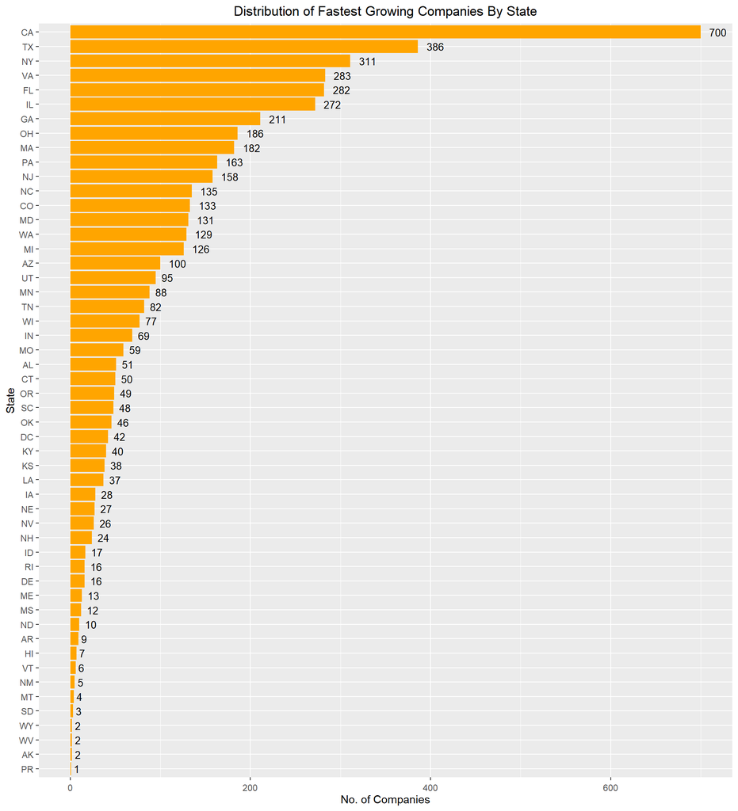

```r
# Answer Question 1 here
topStates <- inc %>% group_by(State) %>% summarise(compCount = n()) %>% mutate(rank = rank(-compCount)) %>% arrange(rank)

ggplot(topStates, aes(x = reorder(State,compCount), y = compCount)) +
  geom_bar(stat = "identity", position = "dodge", fill = "orange") +
  geom_text(aes(label=compCount), hjust=-0.5, color="black", position = position_dodge(0.9), size=3.5) +
  scale_fill_brewer(palette="Paired") +
  theme(axis.text.x=element_text(angle = 0, vjust = 0.5)) +
  theme(plot.title = element_text(hjust = 0.5)) +
  ggtitle("Distribution of Fastest Growing Companies By State") +
  labs(x = "State", y = "No. of Companies") +
  coord_flip()
```

## Quesiton 2

Lets dig in on the state with the 3rd most companies in the data set. Imagine you work for the state and are interested in how many people are employed by companies in different industries. Create a plot that shows the average and/or median employment by industry for companies in this state (only use cases with full data, use R’s `complete.cases()` function.) In addition to this, your graph should show how variable the ranges are, and you should deal with outliers.

```r
# Answer Question 2 here
top3rdState <- inc %>% group_by(State) %>% summarise(compCount = n()) %>% mutate(rank = rank(-compCount)) %>% filter(rank == 3)

print(paste0("Top 3rd state in no. of companies: ",top3rdState$State, " with ", top3rdState$compCount," companies."))
```

```
## [1] "Top 3rd state in no. of companies: NY with 311 companies."
```

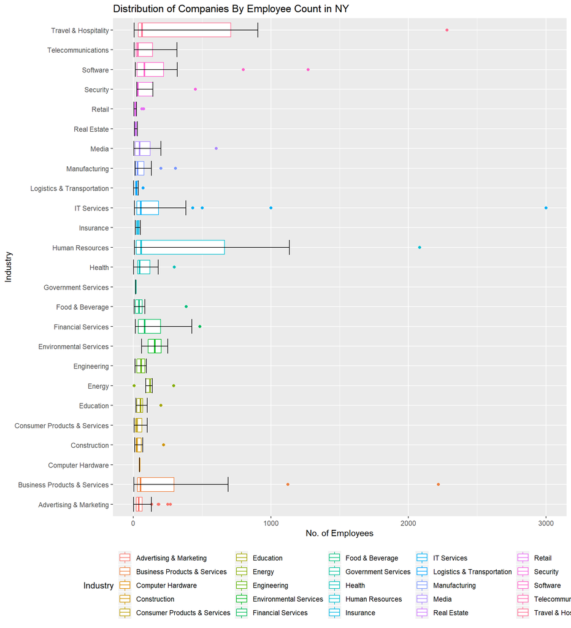

```r
# Filter data for 3rd state in the rank for highest no. of companies
incTop3rdState <- inc %>% filter(State == toString(top3rdState$State)) %>% filter(Employees < 5000)

ggplot(incTop3rdState, aes(x = factor(Industry), y = Employees)) +
  geom_boxplot(aes(colour = Industry), width = 0.7)+
  stat_boxplot(geom ='errorbar') +
  ggtitle("Distribution of Companies By Employee Count in NY") +
  ylab("No. of Employees") +
  xlab("Industry") +
  theme(legend.position="bottom") +
  coord_flip()
```

In order to deal with outliers, I have removed records from New York’s data set with employees > 5000.

## Question 3

Now imagine you work for an investor and want to see which industries generate the most revenue per employee. Create a chart that makes this information clear. Once again, the distribution per industry should be shown.

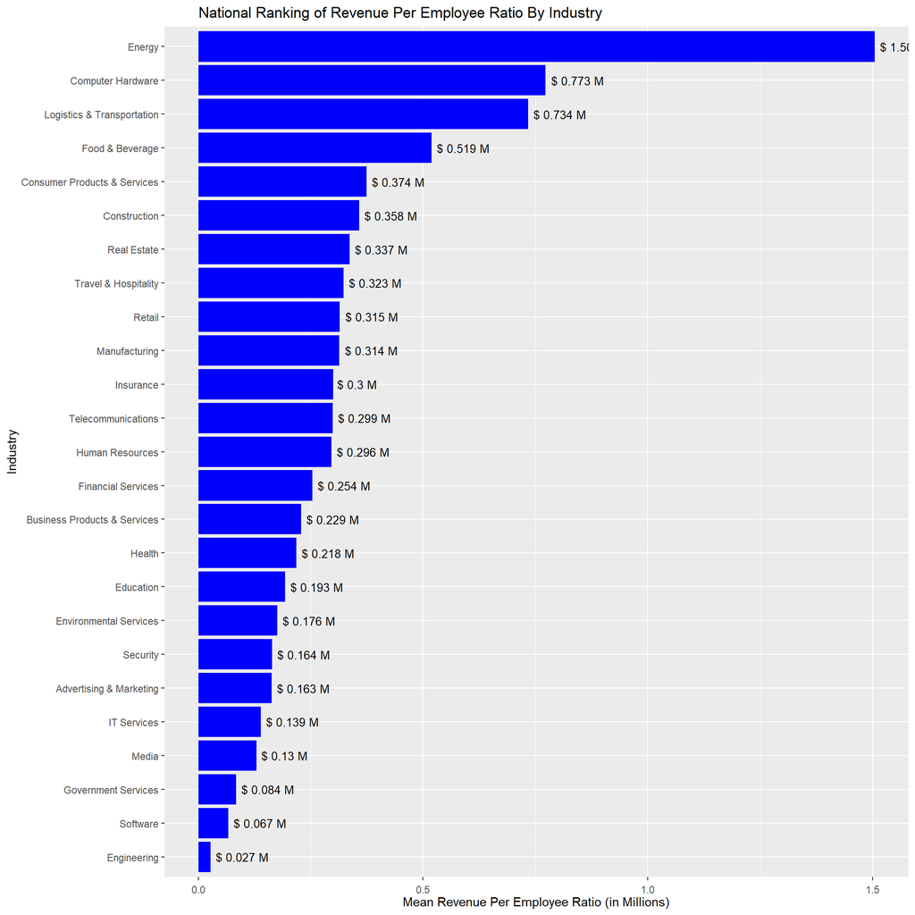

```r
# Answer Question 3 here

# Derive Revenue Per Employee By individual company
revenueEmplRatio <- inc %>% mutate(revEmplRatio = round((Revenue/Employees)/1000000,0))

# Calculate mean of the ratio by industry
revenueEmplRatioMean <- revenueEmplRatio %>% group_by(Industry) %>% summarise(ratio.mean = round(mean(revEmplRatio),3))

ggplot(revenueEmplRatioMean, aes(x = reorder(Industry,ratio.mean), y = ratio.mean)) +
  geom_bar(stat = "identity", position = "dodge", fill = "blue") +
  geom_text(aes(label=paste("$",ratio.mean,"M")), hjust=-0.1, color="black", position = position_dodge(0.9), size=3.5) +
  scale_fill_brewer(palette="Paired") +
  theme(axis.text.x=element_text(angle = 0, vjust = 0.1)) +
  theme(plot.title = element_text(hjust = 0.1)) +
  ggtitle("National Ranking of Revenue Per Employee Ratio By Industry") +
  labs(x = "Industry", y = "Mean Revenue Per Employee Ratio (in Millions)") +
  coord_flip()
```

From the above plot, it can be inferred that Energy industry has by far the highest mean Revenue Per Employee numbers nationally. But from the below Histogram distribution plot including RED dotted line for the mean ratio, referring to the facet for ‘Energy’ industry, it can be observed that there are quite a few outliers.

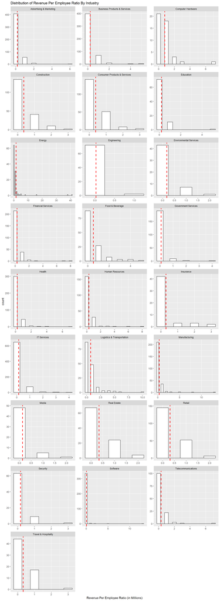

```r
# Distribution of the Ratio by Industry
ggplot(revenueEmplRatio, aes(x=revEmplRatio)) + geom_histogram(binwidth=.5, colour="black", fill="white") +
   # facet_grid(Industry ~.,scales = "free") +
    facet_wrap(Industry ~., scales = "free", ncol = 3) +
    geom_vline(data=revenueEmplRatioMean, aes(xintercept=ratio.mean),
               linetype="dashed", size=1, colour="red")+
    ggtitle("Distribution of Revenue Per Employee Ratio By Industry") +
    xlab("Revenue Per Employee Ratio (in Millions)")
```